# GROUP6 - UDP-Copy1

## Attribute Information

- Attribute 1: (qualitative) **Status of existing checking account**  
  A11 : ... < 0 DM  
  A12 : 0 <= ... < 200 DM  
  A13 : ... >= 200 DM / salary assignments for at least 1 year  
  A14 : no checking account
- Attribute 2: (numerical) **Duration in month**
- Attribute 3: (qualitative) **Credit history**  
  A30 : no credits taken/all credits paid back duly  
  A31 : all credits at this bank paid back duly  
  A32 : existing credits paid back duly till now  
  A33 : delay in paying off in the past  
  A34 : critical account/other credits existing (not at this bank)
- Attribute 4: (qualitative) **Purpose**  
  A40 : car (new)  
  A41 : car (used)  
  A42 : furniture/equipment  
  A43 : radio/television  
  A44 : domestic appliances  
  A45 : repairs  
  A46 : education  
  A47 : vacation  
  A48 : retraining  
  A49 : business  
  A410 : others
- Attribute 5: (numerical) **Credit amount**
- Attibute 6: (qualitative) **Savings account/bonds**  
  A61 : ... < 100 DM  
  A62 : 100 <= ... < 500 DM  
  A63 : 500 <= ... < 1000 DM  
  A64 : .. >= 1000 DM  
  A65 : unknown/ no savings account
- Attribute 7: (qualitative) **Present employment since**  
  A71 : unemployed  
  A72 : ... < 1 year  
  A73 : 1 <= ... < 4 years  
  A74 : 4 <= ... < 7 years  
  A75 : .. >= 7 years
- Attribute 8: (numerical) **Installment rate in percentage of disposable income**
- Attribute 9: (qualitative) **Personal status and sex**  
  A91 : male : divorced/separated  
  A92 : female : divorced/separated/married  
  A93 : male : single  
  A94 : male : married/widowed  
  A95 : female : single
- Attribute 10: (qualitative) **Other debtors / guarantors**  
  A101 : none  
  A102 : co-applicant  
  A103 : guarantor
- Attribute 11: (numerical) **Present residence since**
- Attribute 12: (qualitative) **Property** A121 : real estate  
  A122 : if not A121 : building society savings agreement/life insurance  
  A123 : if not A121/A122 : car or other, not in attribute 6  
  A124 : unknown / no property
- Attribute 13: (numerical) **Age in years**
- Attribute 14: (qualitative) **Other installment plans**  
  A141 : bank  
  A142 : stores  
  A143 : none
- Attribute 15: (qualitative) **Housing**  
  A151 : rent  
  A152 : own  
  A153 : for free
- Attribute 16: (numerical) **Number of existing credits at this bank**
- Attribute 17: (qualitative) **Job**  
  A171 : unemployed/ unskilled - non-resident  
  A172 : unskilled - resident  
  A173 : skilled employee / official  
  A174 : management/ self-employed/highly qualified employee/ officer
- Attribute 18: (numerical) **Number of people being liable to provide maintenance for**
- Attribute 19: (qualitative) **Telephone**  
  A191 : none  
  A192 : yes, registered under the customers name
- Attribute 20: (qualitative) **foreign worker**  
  A201 : yes  
  A202 : no

### Target Variable

- **Cost Matrix**
  - 1 = **Good Risk**
  - 2 = **Bad Risk**

## Import Libraries

```python
import numpy as np
import pandas as pd
import seaborn as sns
from scipy import stats
import scikitplot as skplt
from math import floor,ceil
import statsmodels.api as sm
import matplotlib.pyplot as plt
from sklearn.decomposition import PCA
pd.set_option('display.max_columns', None)
from sklearn.model_selection import train_test_split


import tenseal as ts
import pandas as pd
import torch
from torch import nn, optim
from torch.autograd.variable import Variable
from torch.utils.data import DataLoader, TensorDataset

from keras.models import Sequential
from keras.layers import Dense, LeakyReLU, Dropout
#from keras.optimizers. import Adam
from keras.optimizers.legacy import Adam
from keras.layers import Input
from keras.models import Model
from opacus import PrivacyEngine

from sklearn import preprocessing
import warnings
warnings.simplefilter('ignore', DeprecationWarning)
```

## Read Data

```python
df=pd.read_csv("german.data",sep=" ",header=None)
headers=["Status of existing checking account","Duration in month","Credit history",\
         "Purpose","Credit amount","Savings account/bonds","Present employment since",\
         "Installment rate in percentage of disposable income","Personal status and sex",\
         "Other debtors / guarantors","Present residence since","Property","Age in years",\
        "Other installment plans","Housing","Number of existing credits at this bank",\
        "Job","Number of people being liable to provide maintenance for","Telephone","foreign worker","Cost Matrix(Risk)"]

numerical_attributes = ["Duration in month", "Credit amount", "Installment rate in percentage of disposable income", "Present residence since", "Age in years",\
                        "Number of existing credits at this bank", "Number of people being liable to provide maintenance for"]

df.columns=headers
original_data = df.copy()


Status_of_existing_checking_account={'A14':"no checking account",'A11':"<0 DM", 'A12': "0 <= <200 DM",'A13':">= 200 DM "}
df["Status of existing checking account"]=df["Status of existing checking account"].map(Status_of_existing_checking_account)

Credit_history={"A34":"critical account","A33":"delay in paying off","A32":"existing credits paid back duly till now","A31":"all credits at this bank paid back duly","A30":"no credits taken"}
df["Credit history"]=df["Credit history"].map(Credit_history)

Purpose={"A40" : "car (new)", "A41" : "car (used)", "A42" : "furniture/equipment", "A43" :"radio/television" , "A44" : "domestic appliances", "A45" : "repairs", "A46" : "education", 'A47' : 'vacation','A48' : 'retraining','A49' : 'business','A410' : 'others'}
df["Purpose"]=df["Purpose"].map(Purpose)

Saving_account={"A65" : "no savings account","A61" :"<100 DM","A62" : "100 <= <500 DM","A63" :"500 <= < 1000 DM", "A64" :">= 1000 DM"}
df["Savings account/bonds"]=df["Savings account/bonds"].map(Saving_account)

Present_employment={'A75':">=7 years", 'A74':"4<= <7 years",  'A73':"1<= < 4 years", 'A72':"<1 years",'A71':"unemployed"}
df["Present employment since"]=df["Present employment since"].map(Present_employment)



Personal_status_and_sex={ 'A95':"female:single",'A94':"male:married/widowed",'A93':"male:single", 'A92':"female:divorced/separated/married", 'A91':"male:divorced/separated"}
df["Personal status and sex"]=df["Personal status and sex"].map(Personal_status_and_sex)


Other_debtors_guarantors={'A101':"none", 'A102':"co-applicant", 'A103':"guarantor"}
df["Other debtors / guarantors"]=df["Other debtors / guarantors"].map(Other_debtors_guarantors)


Property={'A121':"real estate", 'A122':"savings agreement/life insurance", 'A123':"car or other", 'A124':"unknown / no property"}
df["Property"]=df["Property"].map(Property)




Other_installment_plans={'A143':"none", 'A142':"store", 'A141':"bank"}
df["Other installment plans"]=df["Other installment plans"].map(Other_installment_plans)

Housing={'A153':"for free", 'A152':"own", 'A151':"rent"}
df["Housing"]=df["Housing"].map(Housing)




Job={'A174':"management/ highly qualified employee", 'A173':"skilled employee / official", 'A172':"unskilled - resident", 'A171':"unemployed/ unskilled  - non-resident"}
df["Job"]=df["Job"].map(Job)

Telephone={'A192':"yes", 'A191':"none"}
df["Telephone"]=df["Telephone"].map(Telephone)



foreign_worker={'A201':"yes", 'A202':"no"}
df["foreign worker"]=df["foreign worker"].map(foreign_worker)



#risk={1:"Good Risk", 2:"Bad Risk"}
#df["Cost Matrix(Risk)"]=df["Cost Matrix(Risk)"].map(risk)
```

## Data Overview

```python
df.head() #top 5 rows of the dataset
```

|  | Status of existing checking account | Duration in month | Credit history | Purpose | Credit amount | Savings account/bonds | Present employment since | Installment rate in percentage of disposable income | Personal status and sex | Other debtors / guarantors | Present residence since | Property | Age in years | Other installment plans | Housing | Number of existing credits at this bank | Job | Number of people being liable to provide maintenance for | Telephone | foreign worker | Cost Matrix(Risk) |
| --- | --- | --- | --- | --- | --- | --- | --- | --- | --- | --- | --- | --- | --- | --- | --- | --- | --- | --- | --- | --- | --- |
| 0 | <0 DM | 6 | critical account | radio/television | 1169 | no savings account | >=7 years | 4 | male:single | none | 4 | real estate | 67 | none | own | 2 | skilled employee / official | 1 | yes | yes | 1 |
| 1 | 0 <= <200 DM | 48 | existing credits paid back duly till now | radio/television | 5951 | <100 DM | 1<= < 4 years | 2 | female:divorced/separated/married | none | 2 | real estate | 22 | none | own | 1 | skilled employee / official | 1 | none | yes | 2 |
| 2 | no checking account | 12 | critical account | education | 2096 | <100 DM | 4<= <7 years | 2 | male:single | none | 3 | real estate | 49 | none | own | 1 | unskilled - resident | 2 | none | yes | 1 |
| 3 | <0 DM | 42 | existing credits paid back duly till now | furniture/equipment | 7882 | <100 DM | 4<= <7 years | 2 | male:single | guarantor | 4 | savings agreement/life insurance | 45 | none | for free | 1 | skilled employee / official | 2 | none | yes | 1 |
| 4 | <0 DM | 24 | delay in paying off | car (new) | 4870 | <100 DM | 1<= < 4 years | 3 | male:single | none | 4 | unknown / no property | 53 | none | for free | 2 | skilled employee / official | 2 | none | yes | 2 |

### Data Info

```python
df.info()
```

```
<class 'pandas.core.frame.DataFrame'>
RangeIndex: 1000 entries, 0 to 999
Data columns (total 21 columns):
 #   Column                                                    Non-Null Count  Dtype
---  ------                                                    --------------  -----
 0   Status of existing checking account                       1000 non-null   object
 1   Duration in month                                         1000 non-null   int64
 2   Credit history                                            1000 non-null   object
 3   Purpose                                                   1000 non-null   object
 4   Credit amount                                             1000 non-null   int64
 5   Savings account/bonds                                     1000 non-null   object
 6   Present employment since                                  1000 non-null   object
 7   Installment rate in percentage of disposable income       1000 non-null   int64
 8   Personal status and sex                                   1000 non-null   object
 9   Other debtors / guarantors                                1000 non-null   object
 10  Present residence since                                   1000 non-null   int64
 11  Property                                                  1000 non-null   object
 12  Age in years                                              1000 non-null   int64
 13  Other installment plans                                   1000 non-null   object
 14  Housing                                                   1000 non-null   object
 15  Number of existing credits at this bank                   1000 non-null   int64
 16  Job                                                       1000 non-null   object
 17  Number of people being liable to provide maintenance for  1000 non-null   int64
 18  Telephone                                                 1000 non-null   object
 19  foreign worker                                            1000 non-null   object
 20  Cost Matrix(Risk)                                         1000 non-null   int64
dtypes: int64(8), object(13)
memory usage: 164.2+ KB
```

```python
df.describe()
```

|  | Duration in month | Credit amount | Installment rate in percentage of disposable income | Present residence since | Age in years | Number of existing credits at this bank | Number of people being liable to provide maintenance for | Cost Matrix(Risk) |
| --- | --- | --- | --- | --- | --- | --- | --- | --- |
| count | 1000.000000 | 1000.000000 | 1000.000000 | 1000.000000 | 1000.000000 | 1000.000000 | 1000.000000 | 1000.000000 |
| mean | 20.903000 | 3271.258000 | 2.973000 | 2.845000 | 35.546000 | 1.407000 | 1.155000 | 1.300000 |
| std | 12.058814 | 2822.736876 | 1.118715 | 1.103718 | 11.375469 | 0.577654 | 0.362086 | 0.458487 |
| min | 4.000000 | 250.000000 | 1.000000 | 1.000000 | 19.000000 | 1.000000 | 1.000000 | 1.000000 |
| 25% | 12.000000 | 1365.500000 | 2.000000 | 2.000000 | 27.000000 | 1.000000 | 1.000000 | 1.000000 |
| 50% | 18.000000 | 2319.500000 | 3.000000 | 3.000000 | 33.000000 | 1.000000 | 1.000000 | 1.000000 |
| 75% | 24.000000 | 3972.250000 | 4.000000 | 4.000000 | 42.000000 | 2.000000 | 1.000000 | 2.000000 |
| max | 72.000000 | 18424.000000 | 4.000000 | 4.000000 | 75.000000 | 4.000000 | 2.000000 | 2.000000 |

## Exploratory Data Analysis (EDA)

## Correlation Matrix

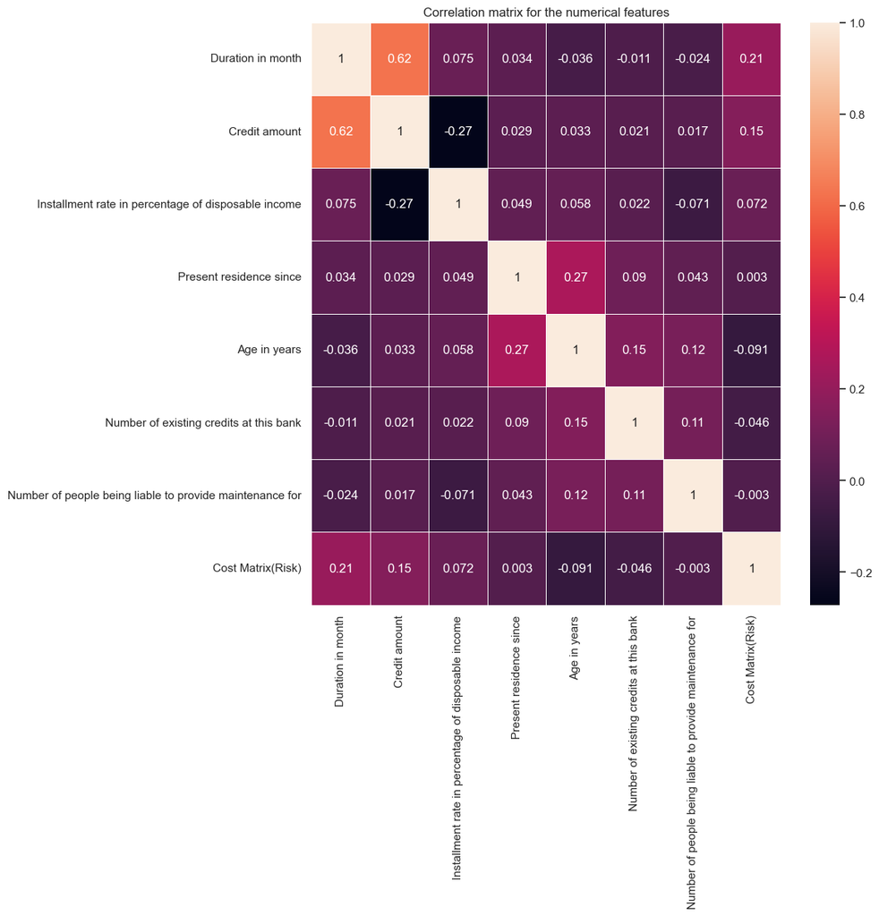

```python
corr = df.corr()

fig, ax = plt.subplots(figsize=(10,10))
ax = sns.heatmap(corr, annot=True, linewidth=0.5, xticklabels=numerical_attributes + ["Cost Matrix(Risk)"])
ax.set_yticklabels(labels=numerical_attributes + ["Cost Matrix(Risk)"], rotation=0)
ax.set_title("Correlation matrix for the numerical features")
plt.show()
```

```python
df_numerical = df.copy()

dummy_columns = ["Credit history", "Purpose", "Personal status and sex", "Other debtors / guarantors", "Property", "Other installment plans", "Housing", \
            "foreign worker", "Status of existing checking account", "Savings account/bonds", "Telephone", "Job", "Present employment since"]

df_numerical = pd.get_dummies(df_numerical, columns=dummy_columns, drop_first=True)
```

```python
 df_numerical.head()
```

|  | Duration in month | Credit amount | Installment rate in percentage of disposable income | Present residence since | Age in years | Number of existing credits at this bank | Number of people being liable to provide maintenance for | Cost Matrix(Risk) | Credit history_critical account | Credit history_delay in paying off | Credit history_existing credits paid back duly till now | Credit history_no credits taken | Purpose_car (new) | Purpose_car (used) | Purpose_domestic appliances | Purpose_education | Purpose_furniture/equipment | Purpose_others | Purpose_radio/television | Purpose_repairs | Purpose_retraining | Personal status and sex_male:divorced/separated | Personal status and sex_male:married/widowed | Personal status and sex_male:single | Other debtors / guarantors_guarantor | Other debtors / guarantors_none | Property_real estate | Property_savings agreement/life insurance | Property_unknown / no property | … |
| --- | --- | --- | --- | --- | --- | --- | --- | --- | --- | --- | --- | --- | --- | --- | --- | --- | --- | --- | --- | --- | --- | --- | --- | --- | --- | --- | --- | --- | --- | --- |
| 0 | 6 | 1169 | 4 | 4 | 67 | 2 | 1 | 1 | 1 | 0 | 0 | 0 | 0 | 0 | 0 | 0 | 0 | 0 | 1 | 0 | 0 | 0 | 0 | 1 | 0 | 1 | 1 | 0 | 0 | … |
| 1 | 48 | 5951 | 2 | 2 | 22 | 1 | 1 | 2 | 0 | 0 | 1 | 0 | 0 | 0 | 0 | 0 | 0 | 0 | 1 | 0 | 0 | 0 | 0 | 0 | 0 | 1 | 1 | 0 | 0 | … |
| 2 | 12 | 2096 | 2 | 3 | 49 | 1 | 2 | 1 | 1 | 0 | 0 | 0 | 0 | 0 | 0 | 1 | 0 | 0 | 0 | 0 | 0 | 0 | 0 | 1 | 0 | 1 | 1 | 0 | 0 | … |
| 3 | 42 | 7882 | 2 | 4 | 45 | 1 | 2 | 1 | 0 | 0 | 1 | 0 | 0 | 0 | 0 | 0 | 1 | 0 | 0 | 0 | 0 | 0 | 0 | 1 | 1 | 0 | 0 | 1 | 0 | … |
| 4 | 24 | 4870 | 3 | 4 | 53 | 2 | 2 | 2 | 0 | 1 | 0 | 0 | 1 | 0 | 0 | 0 | 0 | 0 | 0 | 0 | 0 | 0 | 0 | 1 | 0 | 1 | 0 | 0 | 1 | … |

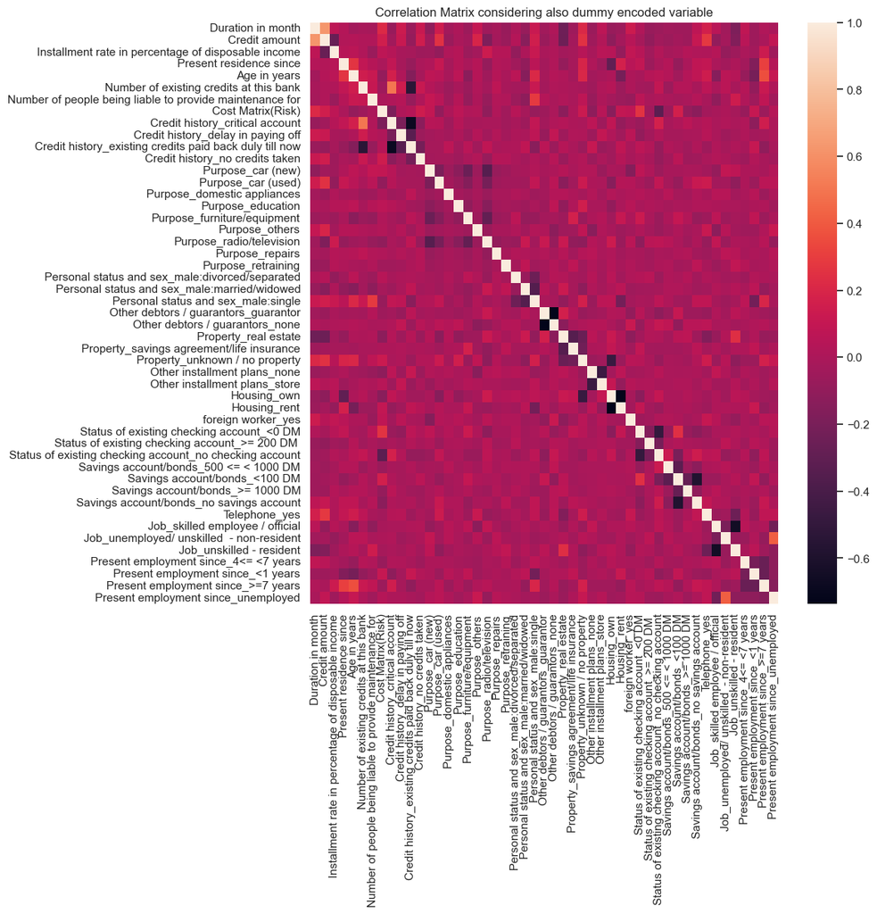

```python
corr = df_numerical.corr()

fig, ax = plt.subplots(figsize=(10,10))
ax = sns.heatmap(corr, xticklabels=corr.columns)
ax.set_yticklabels(labels=corr.columns, rotation=0)
ax.set_title("Correlation Matrix considering also dummy encoded variable")
plt.show()
```

```python
corr_unstacked = corr.unstack().abs()
ranked_corr = corr_unstacked.sort_values(kind="quicksort", ascending=False)
ranked_corr = ranked_corr[ranked_corr != 1]

ranked_corr.head(20)
```

```
Housing_rent                                             Housing_own                                                0.735968
Housing_own                                              Housing_rent                                               0.735968
Other debtors / guarantors_none                          Other debtors / guarantors_guarantor                       0.731408
Other debtors / guarantors_guarantor                     Other debtors / guarantors_none                            0.731408
Credit history_critical account                          Credit history_existing credits paid back duly till now    0.683617
Credit history_existing credits paid back duly till now  Credit history_critical account                            0.683617
Job_skilled employee / official                          Job_unskilled - resident                                   0.652438
Job_unskilled - resident                                 Job_skilled employee / official                            0.652438
Duration in month                                        Credit amount                                              0.624984
Credit amount                                            Duration in month                                          0.624984
Savings account/bonds_no savings account                 Savings account/bonds_<100 DM                              0.583281
Savings account/bonds_<100 DM                            Savings account/bonds_no savings account                   0.583281
Number of existing credits at this bank                  Credit history_existing credits paid back duly till now    0.540354
Credit history_existing credits paid back duly till now  Number of existing credits at this bank                    0.540354
Credit history_critical account                          Number of existing credits at this bank                    0.501364
Number of existing credits at this bank                  Credit history_critical account                            0.501364
Status of existing checking account_no checking account  Status of existing checking account_<0 DM                  0.495358
Status of existing checking account_<0 DM                Status of existing checking account_no checking account    0.495358
Housing_own                                              Property_unknown / no property                             0.476496
Property_unknown / no property                           Housing_own                                                0.476496
dtype: float64
```

```python
column_names=df.columns.tolist()
column_names.remove("Credit amount") #numerical variable
column_names.remove("Age in years") #numerical variable
column_names.remove("Duration in month") #numerical variable
#----------------------------------------------------------------------------------------

column_names_cat={}
for name in column_names:
    column_names_cat[name]=len(df[name].unique().tolist())

    marginal_report_cluster={}
for itr in range(0,np.asarray(list(column_names_cat.values())).max()+1):
    if [k for k,v in column_names_cat.items() if v == itr]:
        marginal_report_cluster[itr]=[k for k,v in column_names_cat.items() if v == itr]

#----------------------------------------------------------------------------------------
for key in marginal_report_cluster.keys():
    marginal_percentage_report=[]
    for name in sorted(marginal_report_cluster[key]):
        data=pd.crosstab(df[name],columns=["Percentage"]).apply(lambda r: (round((r/r.sum())*100,2)), axis=0).reset_index()
        data.columns=[name,"Percentage"]
        data=data.transpose().reset_index()
        [marginal_percentage_report.append(x) for x in data.values.tolist()]
        options=[]
    marginal_percentage_report=pd.DataFrame(marginal_percentage_report)
    [options.append("Category Option "+str(itr)) for itr in range(1,len(marginal_percentage_report.columns))]
    marginal_percentage_report.columns=["Attribute"]+options
```

### Desc Numerical Variables

```python
df[["Credit amount","Age in years","Duration in month"]].describe()
```

|  | Credit amount | Age in years | Duration in month |
| --- | --- | --- | --- |
| count | 1000.000000 | 1000.000000 | 1000.000000 |
| mean | 3271.258000 | 35.546000 | 20.903000 |
| std | 2822.736876 | 11.375469 | 12.058814 |
| min | 250.000000 | 19.000000 | 4.000000 |
| 25% | 1365.500000 | 27.000000 | 12.000000 |
| 50% | 2319.500000 | 33.000000 | 18.000000 |
| 75% | 3972.250000 | 42.000000 | 24.000000 |
| max | 18424.000000 | 75.000000 | 72.000000 |

### Box plot Numerical Variables

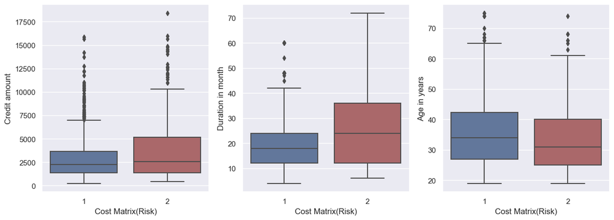

```python
sns.set()
f, axes = plt.subplots(1, 3,figsize=(15,5))
sns.boxplot(y=df["Credit amount"],x=df["Cost Matrix(Risk)"],orient='v' , ax=axes[0],palette=["#5975A4","#B55D60"]) #box plot
sns.boxplot(y=df["Duration in month"],x=df["Cost Matrix(Risk)"], orient='v' , ax=axes[1],palette=["#5975A4","#B55D60"]) #box plot
sns.boxplot(y=df["Age in years"],x=df["Cost Matrix(Risk)"], orient='v' , ax=axes[2],palette=["#5975A4","#B55D60"]) #box plot
plt.show()
```

```python
#converting target variable into numeric
risk={"Good Risk":1, "Bad Risk":0}
df["Cost Matrix(Risk)"]=df["Cost Matrix(Risk)"].map(risk)
```

```python
#view of the dataset for modelling
df.head()
```

|  | Status of existing checking account | Duration in month | Credit history | Purpose | Credit amount | Savings account/bonds | Present employment since | Installment rate in percentage of disposable income | Personal status and sex | Other debtors / guarantors | Present residence since | Property | Age in years | Other installment plans | Housing | Number of existing credits at this bank | Job | Number of people being liable to provide maintenance for | Telephone | foreign worker | Cost Matrix(Risk) |
| --- | --- | --- | --- | --- | --- | --- | --- | --- | --- | --- | --- | --- | --- | --- | --- | --- | --- | --- | --- | --- | --- |
| 0 | <0 DM | 6 | critical account | radio/television | 1169 | no savings account | >=7 years | 4 | male:single | none | 4 | real estate | 67 | none | own | 2 | skilled employee / official | 1 | yes | yes | NaN |
| 1 | 0 <= <200 DM | 48 | existing credits paid back duly till now | radio/television | 5951 | <100 DM | 1<= < 4 years | 2 | female:divorced/separated/married | none | 2 | real estate | 22 | none | own | 1 | skilled employee / official | 1 | none | yes | NaN |
| 2 | no checking account | 12 | critical account | education | 2096 | <100 DM | 4<= <7 years | 2 | male:single | none | 3 | real estate | 49 | none | own | 1 | unskilled - resident | 2 | none | yes | NaN |
| 3 | <0 DM | 42 | existing credits paid back duly till now | furniture/equipment | 7882 | <100 DM | 4<= <7 years | 2 | male:single | guarantor | 4 | savings agreement/life insurance | 45 | none | for free | 1 | skilled employee / official | 2 | none | yes | NaN |
| 4 | <0 DM | 24 | delay in paying off | car (new) | 4870 | <100 DM | 1<= < 4 years | 3 | male:single | none | 4 | unknown / no property | 53 | none | for free | 2 | skilled employee / official | 2 | none | yes | NaN |

### Train/Test Split

```python
X = df.drop('Cost Matrix(Risk)', 1).values #independent variables
y = df["Cost Matrix(Risk)"].values #target variables
```

```python
# Spliting dataset into train and test version
X_train, X_test, y_train, y_test = train_test_split(X, y, test_size = 0.30,random_state=42)
```

```python
context = ts.context(ts.SCHEME_TYPE.CKKS, poly_modulus_degree=8192, coeff_mod_bit_sizes=[60,40,40,60])
context.global_scale = pow(2,10)
```

```python
le = preprocessing.LabelEncoder()
for column in df.columns:
    if df[column].dtype == type(object):
        df[column] = le.fit_transform(df[column])
```

```python
df = torch.tensor(df.values).float()
```

```python
encrypted_data = []
encrypted_data = [ts.ckks_vector(context, x.tolist()) for x in df]
```

```python
print(len(encrypted_data))
```

```
1000
```

```python
#batch the data
batch_size = 64
num_batches = len(encrypted_data) // batch_size
encrypted_batches = [encrypted_data[i:i + batch_size] for i in range(0,len(encrypted_data), batch_size)]
```

```python
#Define Generator
def create_generator():
    generator = Sequential()
    generator.add(Dense(units=256, input_dim=100))
    generator.add(LeakyReLU(0.2))

    generator.add(Dense(units=512))
    generator.add(LeakyReLU(0.2))

    generator.add(Dense(units=1024))
    generator.add(LeakyReLU(0.2))

    generator.add(Dense(units=data.shape[1], activation='tanh'))

    generator.compile(loss='binary_crossentropy', optimizer=Adam(learning_rate=0.0002, beta_1=0.5))
    return generator
```

```python
#Define discriminator
def create_discriminator():
    discriminator = Sequential()
    discriminator.add(Dense(units=256, input_dim=data.shape[1]))
    discriminator.add(LeakyReLU(0.2))
    discriminator.add(Dropout(0.3))

    discriminator.add(Dense(units=512))
    discriminator.add(LeakyReLU(0.2))
    discriminator.add(Dropout(0.3))

    discriminator.add(Dense(units=256))
    discriminator.add(Dense(units=0))
    discriminator.add(LeakyReLU(0.2))

    discriminator.add(Dense(units=1, activation='sigmoid'))

    discriminator.compile(loss='binary_crossentropy', optimizer=Adam(learning_rate=0.0002, beta_1=0.5))
    return discriminator
```

```python
# Define GAN
def create_gan(discriminator, generator):
    discriminator.trainable = False
    gan_input = Input(shape=(100,))
    x = generator(gan_input)
    gan_output = discriminator(x)
    gan = Model(inputs=gan_input, outputs=gan_output)
    gan.compile(loss= 'binary_crossentropy', optimizer='adam')
    return gan
```

```python
#train GAN model
def train_gan(gan, generator, discriminator, epochs=1, batch_size=64):
    for e in range(epochs):
        for batch in encrypted_batches:
            noise = np.random.normal(0,1,[batch_size,100])
            generated_data = generator.predict(noise)
            #decrypted_batch = [enc_val.decrypt() for enc_val in batch]
            #real_data = Variable(torch.Tensor(decrypted_batch))
            real_data = batch
            discriminator.trainable = True
            discriminator.train_on_batch(real_data,np.ones((batch_size,)))
            discriminator.train_on_batch(generated_data,np.zeros((batch_size,)))
            discriminator.trainable = False
            gan.train_on_batch(noise, np.ones((batch_size,)))
```

```python
#train the models
generator = create_generator()
discriminator = create_discriminator()
```

```python
gan = create_gan(discriminator, generator)
train_gan(gan,generator, discriminator)
```

[output not shown]